# Optimal Treatment Analysis

## Outcome Variable

**Outcome Variable:** whz

## Predictor Variables

**Intervention Variable:** gagebrth

**Adjustment Set:**

- arm
- sex
- W_mage
- meducyrs
- feducyrs
- hhwealth_quart
- brthmon
- W_parity
- impsan
- delta_W_mage
- delta_meducyrs
- delta_feducyrs
- delta_hhwealth_quart
- delta_brthmon
- delta_W_parity
- delta_impsan

## Stratifying Variables

The analysis was stratified on these variable(s):

- agecat
- studyid
- country

## Data Summary

| agecat | studyid | country | gagebrth | n_cell | n |
| --- | --- | --- | --- | --- | --- |
| Birth | ki1000108-CMC-V-BCS-2002 | INDIA | Full or late term | 53 | 86 |
| Birth | ki1000108-CMC-V-BCS-2002 | INDIA | Preterm | 11 | 86 |
| Birth | ki1000108-CMC-V-BCS-2002 | INDIA | Early term | 22 | 86 |
| Birth | ki1000108-IRC | INDIA | Full or late term | 213 | 328 |
| Birth | ki1000108-IRC | INDIA | Preterm | 32 | 328 |
| Birth | ki1000108-IRC | INDIA | Early term | 83 | 328 |
| Birth | ki1000109-EE | PAKISTAN | Full or late term | 9 | 177 |
| Birth | ki1000109-EE | PAKISTAN | Preterm | 132 | 177 |
| Birth | ki1000109-EE | PAKISTAN | Early term | 36 | 177 |
| Birth | ki1017093c-NIH-Crypto | BANGLADESH | Full or late term | 160 | 707 |
| Birth | ki1017093c-NIH-Crypto | BANGLADESH | Preterm | 240 | 707 |
| Birth | ki1017093c-NIH-Crypto | BANGLADESH | Early term | 307 | 707 |
| Birth | ki1101329-Keneba | GAMBIA | Full or late term | 709 | 1439 |
| Birth | ki1101329-Keneba | GAMBIA | Preterm | 206 | 1439 |
| Birth | ki1101329-Keneba | GAMBIA | Early term | 524 | 1439 |
| Birth | ki1119695-PROBIT | BELARUS | Full or late term | 7074 | 13830 |
| Birth | ki1119695-PROBIT | BELARUS | Preterm | 468 | 13830 |
| Birth | ki1119695-PROBIT | BELARUS | Early term | 6288 | 13830 |
| Birth | ki1135781-COHORTS | GUATEMALA | Full or late term | 323 | 572 |
| Birth | ki1135781-COHORTS | GUATEMALA | Preterm | 78 | 572 |
| Birth | ki1135781-COHORTS | GUATEMALA | Early term | 171 | 572 |
| Birth | ki1135781-COHORTS | INDIA | Full or late term | 553 | 1229 |
| Birth | ki1135781-COHORTS | INDIA | Preterm | 259 | 1229 |
| Birth | ki1135781-COHORTS | INDIA | Early term | 417 | 1229 |
| Birth | ki1135781-COHORTS | PHILIPPINES | Full or late term | 1135 | 2874 |
| Birth | ki1135781-COHORTS | PHILIPPINES | Preterm | 579 | 2874 |
| Birth | ki1135781-COHORTS | PHILIPPINES | Early term | 1160 | 2874 |
| Birth | kiGH5241-JiVitA-3 | BANGLADESH | Full or late term | 9668 | 17161 |
| Birth | kiGH5241-JiVitA-3 | BANGLADESH | Preterm | 2755 | 17161 |
| Birth | kiGH5241-JiVitA-3 | BANGLADESH | Early term | 4738 | 17161 |

[output cut: 66 more lines]

The following strata were considered:

- agecat: 24 months, studyid: ki1000108-CMC-V-BCS-2002, country: INDIA
- agecat: 24 months, studyid: ki1000108-IRC, country: INDIA
- agecat: 24 months, studyid: ki1000109-EE, country: PAKISTAN
- agecat: 24 months, studyid: ki1017093c-NIH-Crypto, country: BANGLADESH
- agecat: 24 months, studyid: ki1066203-TanzaniaChild2, country: TANZANIA, UNITED REPUBLIC OF
- agecat: 24 months, studyid: ki1101329-Keneba, country: GAMBIA
- agecat: 24 months, studyid: ki1119695-PROBIT, country: BELARUS
- agecat: 24 months, studyid: ki1135781-COHORTS, country: GUATEMALA
- agecat: 24 months, studyid: ki1135781-COHORTS, country: INDIA
- agecat: 24 months, studyid: ki1135781-COHORTS, country: PHILIPPINES
- agecat: 24 months, studyid: kiGH5241-JiVitA-3, country: BANGLADESH
- agecat: 6 months, studyid: ki1000108-CMC-V-BCS-2002, country: INDIA
- agecat: 6 months, studyid: ki1000108-IRC, country: INDIA
- agecat: 6 months, studyid: ki1000109-EE, country: PAKISTAN
- agecat: 6 months, studyid: ki1017093c-NIH-Crypto, country: BANGLADESH
- agecat: 6 months, studyid: ki1066203-TanzaniaChild2, country: TANZANIA, UNITED REPUBLIC OF
- agecat: 6 months, studyid: ki1101329-Keneba, country: GAMBIA
- agecat: 6 months, studyid: ki1119695-PROBIT, country: BELARUS
- agecat: 6 months, studyid: ki1135781-COHORTS, country: GUATEMALA
- agecat: 6 months, studyid: ki1135781-COHORTS, country: INDIA
- agecat: 6 months, studyid: ki1135781-COHORTS, country: PHILIPPINES
- agecat: 6 months, studyid: kiGH5241-JiVitA-3, country: BANGLADESH
- agecat: Birth, studyid: ki1000108-CMC-V-BCS-2002, country: INDIA
- agecat: Birth, studyid: ki1000108-IRC, country: INDIA
- agecat: Birth, studyid: ki1000109-EE, country: PAKISTAN
- agecat: Birth, studyid: ki1017093c-NIH-Crypto, country: BANGLADESH
- agecat: Birth, studyid: ki1101329-Keneba, country: GAMBIA
- agecat: Birth, studyid: ki1119695-PROBIT, country: BELARUS
- agecat: Birth, studyid: ki1135781-COHORTS, country: GUATEMALA
- agecat: Birth, studyid: ki1135781-COHORTS, country: INDIA
- agecat: Birth, studyid: ki1135781-COHORTS, country: PHILIPPINES
- agecat: Birth, studyid: kiGH5241-JiVitA-3, country: BANGLADESH

### Dropped Strata

Some strata were dropped due to rare outcomes:

- agecat: 24 months, studyid: ki1066203-TanzaniaChild2, country: TANZANIA, UNITED REPUBLIC OF

## Methods Detail

We’re interested in the causal parameters $E[Y_a]$ for all values of $a \in \mathcal{A}$. These parameters represent the mean outcome if, possibly contrary to fact, we intervened to set all units to have $A=a$. Under the randomization and positivity assumptions, these are identified by the statistical parameters $\psi_a=E_W[E_{Y|A,W}(Y|A=a,W)]$. In addition, we’re interested in the mean of $Y$, $E[Y]$ under no intervention (the observed mean). We will estimate these parameters by using SuperLearner to fit the relevant likelihood factors – $E_{Y|A,W}(Y|A=a,W)$ and $p(A=a|W)$, and then updating our likelihood fit using a joint TMLE.

For unadjusted analyses ($W=\{\}$), initial likelihoods were estimated using Lrnr_glm to estimate the simple $E(Y|A)$ and Lrnr_mean to estimate $p(A)$. For adjusted analyses, a small library containing Lrnr_glmnet, Lrnr_xgboost, and Lrnr_mean was used.

Having estimated these parameters, we will then use the delta method to estimate relative risks and attributable risks relative to a prespecified baseline level of $A$.

# Results Detail

## Results Plots

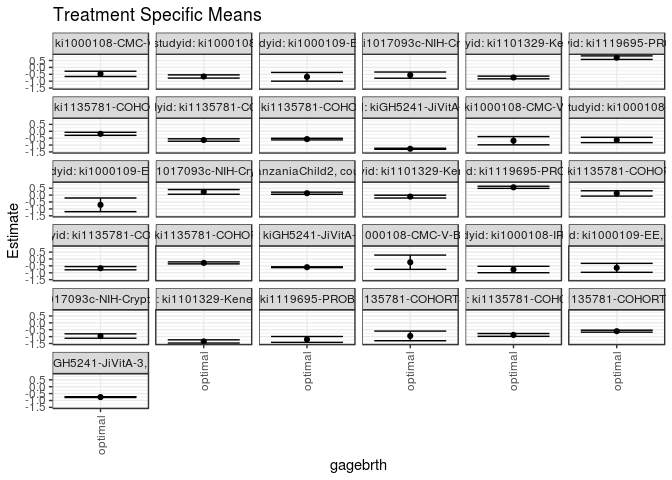

## Results Table

### Parameter: TSM

| agecat | studyid | country | intervention_level | baseline_level | estimate | ci_lower | ci_upper |
| --- | --- | --- | --- | --- | --- | --- | --- |
| Birth | ki1000108-CMC-V-BCS-2002 | INDIA | optimal | observed | -0.2369490 | -0.7542340 | 0.2803360 |
| Birth | ki1000108-IRC | INDIA | optimal | observed | -0.7644248 | -0.9964969 | -0.5323527 |
| Birth | ki1000109-EE | PAKISTAN | optimal | observed | -0.6420309 | -0.9669276 | -0.3171342 |
| Birth | ki1017093c-NIH-Crypto | BANGLADESH | optimal | observed | -0.9578436 | -1.1180893 | -0.7975980 |
| Birth | ki1101329-Keneba | GAMBIA | optimal | observed | -1.3481886 | -1.4644017 | -1.2319755 |
| Birth | ki1119695-PROBIT | BELARUS | optimal | observed | -1.2046450 | -1.4177070 | -0.9915830 |
| Birth | ki1135781-COHORTS | GUATEMALA | optimal | observed | -0.9487396 | -1.2975141 | -0.5999651 |
| Birth | ki1135781-COHORTS | INDIA | optimal | observed | -0.8770334 | -0.9787252 | -0.7753415 |
| Birth | ki1135781-COHORTS | PHILIPPINES | optimal | observed | -0.6059086 | -0.6780958 | -0.5337214 |
| Birth | kiGH5241-JiVitA-3 | BANGLADESH | optimal | observed | -0.7538159 | -0.7822244 | -0.7254075 |
| 6 months | ki1000108-CMC-V-BCS-2002 | INDIA | optimal | observed | -0.6872134 | -0.9860599 | -0.3883669 |
| 6 months | ki1000108-IRC | INDIA | optimal | observed | -0.6317331 | -0.8248170 | -0.4386493 |
| 6 months | ki1000109-EE | PAKISTAN | optimal | observed | -0.7050477 | -1.2013790 | -0.2087164 |
| 6 months | ki1017093c-NIH-Crypto | BANGLADESH | optimal | observed | 0.2350489 | 0.0640858 | 0.4060119 |
| 6 months | ki1066203-TanzaniaChild2 | TANZANIA, UNITED REPUBLIC OF | optimal | observed | 0.1387975 | 0.0620023 | 0.2155927 |
| 6 months | ki1101329-Keneba | GAMBIA | optimal | observed | -0.1080909 | -0.2106315 | -0.0055503 |
| 6 months | ki1119695-PROBIT | BELARUS | optimal | observed | 0.5672390 | 0.4883381 | 0.6461398 |
| 6 months | ki1135781-COHORTS | GUATEMALA | optimal | observed | 0.1217797 | -0.0709964 | 0.3145558 |
| 6 months | ki1135781-COHORTS | INDIA | optimal | observed | -0.6699844 | -0.7878502 | -0.5521187 |
| 6 months | ki1135781-COHORTS | PHILIPPINES | optimal | observed | -0.2838423 | -0.3540590 | -0.2136256 |
| 6 months | kiGH5241-JiVitA-3 | BANGLADESH | optimal | observed | -0.5974241 | -0.6287208 | -0.5661274 |
| 24 months | ki1000108-CMC-V-BCS-2002 | INDIA | optimal | observed | -0.4683620 | -0.6584584 | -0.2782655 |
| 24 months | ki1000108-IRC | INDIA | optimal | observed | -0.6583963 | -0.7755365 | -0.5412560 |
| 24 months | ki1000109-EE | PAKISTAN | optimal | observed | -0.6825733 | -0.9990553 | -0.3660914 |
| 24 months | ki1017093c-NIH-Crypto | BANGLADESH | optimal | observed | -0.5611448 | -0.7858747 | -0.3364149 |
| 24 months | ki1101329-Keneba | GAMBIA | optimal | observed | -0.7322962 | -0.8312084 | -0.6333839 |
| 24 months | ki1119695-PROBIT | BELARUS | optimal | observed | 0.7060203 | 0.5767351 | 0.8353055 |
| 24 months | ki1135781-COHORTS | GUATEMALA | optimal | observed | -0.1854283 | -0.2955492 | -0.0753074 |
| 24 months | ki1135781-COHORTS | INDIA | optimal | observed | -0.6358900 | -0.7239832 | -0.5477967 |
| 24 months | ki1135781-COHORTS | PHILIPPINES | optimal | observed | -0.5691820 | -0.6268518 | -0.5115123 |
| 24 months | kiGH5241-JiVitA-3 | BANGLADESH | optimal | observed | -1.2707471 | -1.3065106 | -1.2349835 |

### Parameter: E(Y)

| agecat | studyid | country | intervention_level | baseline_level | estimate | ci_lower | ci_upper |
| --- | --- | --- | --- | --- | --- | --- | --- |
| Birth | ki1000108-CMC-V-BCS-2002 | INDIA | observed | observed | -0.4648256 | -0.7643210 | -0.1653302 |
| Birth | ki1000108-IRC | INDIA | observed | observed | -1.0135366 | -1.2024730 | -0.8246002 |
| Birth | ki1000109-EE | PAKISTAN | observed | observed | -0.3333051 | -0.5209779 | -0.1456323 |
| Birth | ki1017093c-NIH-Crypto | BANGLADESH | observed | observed | -1.2441513 | -1.3281130 | -1.1601897 |
| Birth | ki1101329-Keneba | GAMBIA | observed | observed | -1.2295969 | -1.2924879 | -1.1667060 |
| Birth | ki1119695-PROBIT | BELARUS | observed | observed | -1.1448633 | -1.3544229 | -0.9353037 |
| Birth | ki1135781-COHORTS | GUATEMALA | observed | observed | -1.0358042 | -1.1559527 | -0.9156557 |
| Birth | ki1135781-COHORTS | INDIA | observed | observed | -1.0098535 | -1.0741510 | -0.9455561 |
| Birth | ki1135781-COHORTS | PHILIPPINES | observed | observed | -0.7417745 | -0.7882773 | -0.6952718 |
| Birth | kiGH5241-JiVitA-3 | BANGLADESH | observed | observed | -0.7794837 | -0.7988174 | -0.7601500 |
| 6 months | ki1000108-CMC-V-BCS-2002 | INDIA | observed | observed | -0.4909778 | -0.6451612 | -0.3367945 |
| 6 months | ki1000108-IRC | INDIA | observed | observed | -0.5999270 | -0.7403711 | -0.4594828 |
| 6 months | ki1000109-EE | PAKISTAN | observed | observed | -0.7747022 | -0.8887874 | -0.6606170 |
| 6 months | ki1017093c-NIH-Crypto | BANGLADESH | observed | observed | 0.0297622 | -0.0491685 | 0.1086930 |
| 6 months | ki1066203-TanzaniaChild2 | TANZANIA, UNITED REPUBLIC OF | observed | observed | 0.0815655 | 0.0271217 | 0.1360092 |
| 6 months | ki1101329-Keneba | GAMBIA | observed | observed | -0.1978013 | -0.2594875 | -0.1361150 |
| 6 months | ki1119695-PROBIT | BELARUS | observed | observed | 0.5792439 | 0.5193388 | 0.6391490 |
| 6 months | ki1135781-COHORTS | GUATEMALA | observed | observed | 0.1864566 | 0.1024304 | 0.2704827 |
| 6 months | ki1135781-COHORTS | INDIA | observed | observed | -0.6460976 | -0.7081436 | -0.5840516 |
| 6 months | ki1135781-COHORTS | PHILIPPINES | observed | observed | -0.2920968 | -0.3336448 | -0.2505489 |
| 6 months | kiGH5241-JiVitA-3 | BANGLADESH | observed | observed | -0.5906060 | -0.6106295 | -0.5705826 |
| 24 months | ki1000108-CMC-V-BCS-2002 | INDIA | observed | observed | -0.5369143 | -0.6415957 | -0.4322329 |
| 24 months | ki1000108-IRC | INDIA | observed | observed | -0.7414957 | -0.8350522 | -0.6479392 |
| 24 months | ki1000109-EE | PAKISTAN | observed | observed | -1.0120238 | -1.1588493 | -0.8651984 |
| 24 months | ki1017093c-NIH-Crypto | BANGLADESH | observed | observed | -0.6103502 | -0.7050157 | -0.5156847 |
| 24 months | ki1101329-Keneba | GAMBIA | observed | observed | -0.7953404 | -0.8531640 | -0.7375168 |
| 24 months | ki1119695-PROBIT | BELARUS | observed | observed | 0.6874295 | 0.5756922 | 0.7991668 |
| 24 months | ki1135781-COHORTS | GUATEMALA | observed | observed | -0.2397001 | -0.3082360 | -0.1711643 |
| 24 months | ki1135781-COHORTS | INDIA | observed | observed | -0.5717874 | -0.6260792 | -0.5174955 |
| 24 months | ki1135781-COHORTS | PHILIPPINES | observed | observed | -0.6079283 | -0.6449298 | -0.5709269 |
| 24 months | kiGH5241-JiVitA-3 | BANGLADESH | observed | observed | -1.2935654 | -1.3174540 | -1.2696768 |

### Parameter: PAR

| agecat | studyid | country | intervention_level | baseline_level | estimate | ci_lower | ci_upper |
| --- | --- | --- | --- | --- | --- | --- | --- |
| Birth | ki1000108-CMC-V-BCS-2002 | INDIA | optimal | observed | -0.2278766 | -0.6323165 | 0.1765634 |
| Birth | ki1000108-IRC | INDIA | optimal | observed | -0.2491118 | -0.3960248 | -0.1021988 |
| Birth | ki1000109-EE | PAKISTAN | optimal | observed | 0.3087258 | 0.0473444 | 0.5701073 |
| Birth | ki1017093c-NIH-Crypto | BANGLADESH | optimal | observed | -0.2863077 | -0.4330746 | -0.1395408 |
| Birth | ki1101329-Keneba | GAMBIA | optimal | observed | 0.1185916 | 0.0150647 | 0.2221185 |
| Birth | ki1119695-PROBIT | BELARUS | optimal | observed | 0.0597816 | -0.0106668 | 0.1302301 |
| Birth | ki1135781-COHORTS | GUATEMALA | optimal | observed | -0.0870646 | -0.4062484 | 0.2321192 |
| Birth | ki1135781-COHORTS | INDIA | optimal | observed | -0.1328202 | -0.2076564 | -0.0579840 |
| Birth | ki1135781-COHORTS | PHILIPPINES | optimal | observed | -0.1358660 | -0.1923850 | -0.0793469 |
| Birth | kiGH5241-JiVitA-3 | BANGLADESH | optimal | observed | -0.0256678 | -0.0445220 | -0.0068136 |
| 6 months | ki1000108-CMC-V-BCS-2002 | INDIA | optimal | observed | 0.1962355 | -0.0716755 | 0.4641466 |
| 6 months | ki1000108-IRC | INDIA | optimal | observed | 0.0318062 | -0.1011551 | 0.1647674 |
| 6 months | ki1000109-EE | PAKISTAN | optimal | observed | -0.0696545 | -0.5532924 | 0.4139834 |
| 6 months | ki1017093c-NIH-Crypto | BANGLADESH | optimal | observed | -0.2052866 | -0.3541692 | -0.0564041 |
| 6 months | ki1066203-TanzaniaChild2 | TANZANIA, UNITED REPUBLIC OF | optimal | observed | -0.0572321 | -0.1138515 | -0.0006126 |
| 6 months | ki1101329-Keneba | GAMBIA | optimal | observed | -0.0897104 | -0.1707465 | -0.0086743 |
| 6 months | ki1119695-PROBIT | BELARUS | optimal | observed | 0.0120049 | -0.0385862 | 0.0625960 |
| 6 months | ki1135781-COHORTS | GUATEMALA | optimal | observed | 0.0646769 | -0.0959934 | 0.2253472 |
| 6 months | ki1135781-COHORTS | INDIA | optimal | observed | 0.0238869 | -0.0776702 | 0.1254440 |
| 6 months | ki1135781-COHORTS | PHILIPPINES | optimal | observed | -0.0082545 | -0.0651579 | 0.0486489 |
| 6 months | kiGH5241-JiVitA-3 | BANGLADESH | optimal | observed | 0.0068181 | -0.0181190 | 0.0317551 |
| 24 months | ki1000108-CMC-V-BCS-2002 | INDIA | optimal | observed | -0.0685523 | -0.2357997 | 0.0986951 |
| 24 months | ki1000108-IRC | INDIA | optimal | observed | -0.0830994 | -0.1551062 | -0.0110927 |
| 24 months | ki1000109-EE | PAKISTAN | optimal | observed | -0.3294505 | -0.6271057 | -0.0317953 |
| 24 months | ki1017093c-NIH-Crypto | BANGLADESH | optimal | observed | -0.0492054 | -0.2581138 | 0.1597030 |
| 24 months | ki1101329-Keneba | GAMBIA | optimal | observed | -0.0630442 | -0.1421686 | 0.0160802 |
| 24 months | ki1119695-PROBIT | BELARUS | optimal | observed | -0.0185908 | -0.0740992 | 0.0369177 |
| 24 months | ki1135781-COHORTS | GUATEMALA | optimal | observed | -0.0542719 | -0.1428934 | 0.0343497 |
| 24 months | ki1135781-COHORTS | INDIA | optimal | observed | 0.0641026 | -0.0076198 | 0.1358250 |
| 24 months | ki1135781-COHORTS | PHILIPPINES | optimal | observed | -0.0387463 | -0.0849648 | 0.0074722 |
| 24 months | kiGH5241-JiVitA-3 | BANGLADESH | optimal | observed | -0.0228183 | -0.0492300 | 0.0035934 |